# Data exploration

## Setting up the exercise

We start by importing libraries and the dataset.

```python
# Load libraries
import pandas as pd # Import pandas
import matplotlib.pyplot as plt # Import the pyplot module from matplotlib
import seaborn as sns # Import seaborn

# Import the dataset specifying which Excel sheet name to load the data from
df_majors = pd.read_csv('https://raw.githubusercontent.com/ELSTE-Master/Data-Science/main/Data/Smith_glass_post_NYT_data_majors.csv')
df_traces = pd.read_csv('https://raw.githubusercontent.com/ELSTE-Master/Data-Science/main/Data/Smith_glass_post_NYT_data_traces.csv')
```

Take a minute to explore both datasets using the material from last week. Remember the cheat sheets for various Pandas functions. The typical questions you want to address are:

- What **columns** are contained in the DataFrame?
- What **types** of data are each columns? (e.g., integer → `int`, decimal values →`float`, strings → `objects` )
- What columns contain:
  - **Numerical data** → contain measurable quantities in numerical format and allow mathematical operations
  - **Categorical data** → represent categories or groups and describe *qualities* or *characteristics*, not quantities.

**Questions**

Based on your exploration of the trace elements dataset:

- Is a labelled **index** relevant? In other words, do we want to access **rows** using **labels** (→ `.loc`) or using **positions** (→ `.iloc`)?
- Same question for columns?

**Answer**

There is no right or wrong! But looking at the data, using **positions for index** and **labels for columns** is probably the most logical way to go.

- What column**s** can be used as grouping variables?

**Good reference book**

The use of this dataset is inspired by the by the book *Introduction to Python in Earth Science Data Analysis: From Descriptive Statistics to Machine Learning* by Petrelli (2021).

### Basics of plotting in Python

Listing 1 also loads two libraries for plotting:

- [**Matplotlib**](https://matplotlib.org/stable/users/explain/quick_start.html) is the library for plotting in Python. It allows for the finest and most comprehensive level of customisation, but it take some time to get used to. You can visit [Matplotlib’s gallery](https://matplotlib.org/stable/gallery/index.html) to get some inspiration.
- [**Seaborn**](https://seaborn.pydata.org/tutorial/introduction) is built on Matplotlib, but provides some higher-level functions to easily produce stats-oriented plots. It looks good by default, but finer customisation might be difficult and might result to using Matplotlib. Again, check out [Seaborn’s gallery](https://seaborn.pydata.org/examples/index.html).

Here again, the idea is not to make you expert in *Matplotlib* or *Seaborn*, but rather to provide you with the minimum knowledge for you to further explore this tools in the context of your research.

**Good plotting gallery**

Trying to find some inspiration to get creative on data representation? Check out [The Python Graph Gallery](https://python-graph-gallery.com) website.

#### Components of a Figure

Let’s start to look at the basic components of a *Matplotlib* figure. There are two “hosts” to any plot (Figure 1):

1. A **Figure** represents the main canevas;
2. **Axes** are contained within the figure and is where most of the plotting will occur.

The easiest way to define a figure is using the `subplots()` function ([doc](https://matplotlib.org/stable/api/_as_gen/matplotlib.pyplot.subplots.html); Listing 2). Note that the code returns two variables - `fig` and `ax` - which are the figure and the axes, respectively.

Listing 2: Define a figure and one axes.

```python
import matplotlib.pyplot as plt
fig, ax = plt.subplots()
```

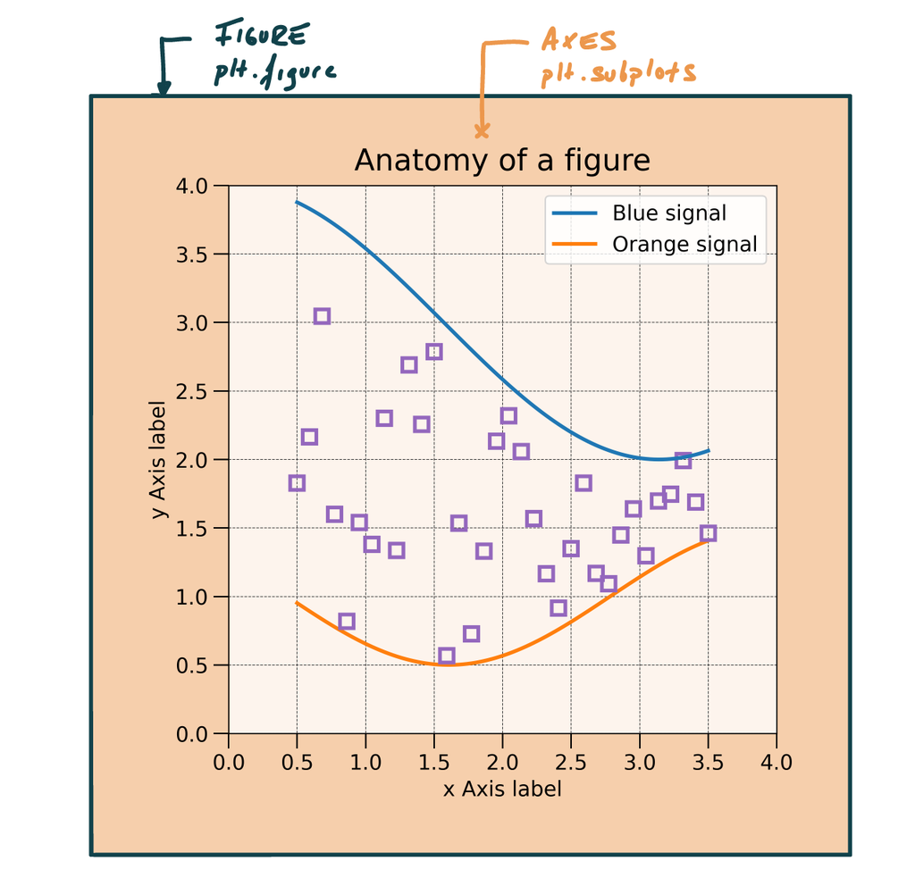

Figure 1: Main figure and axes of a *Matplotlib* figure

Most additional components of a plot are controlled via the `ax` variable, which can be used to (Figure 2):

- *Plot* (e.g., line plot or scatter plots)
- *Set labels* (e.g., x-label, y-label, title)
- Add various *components* (e.g., legend, grid)

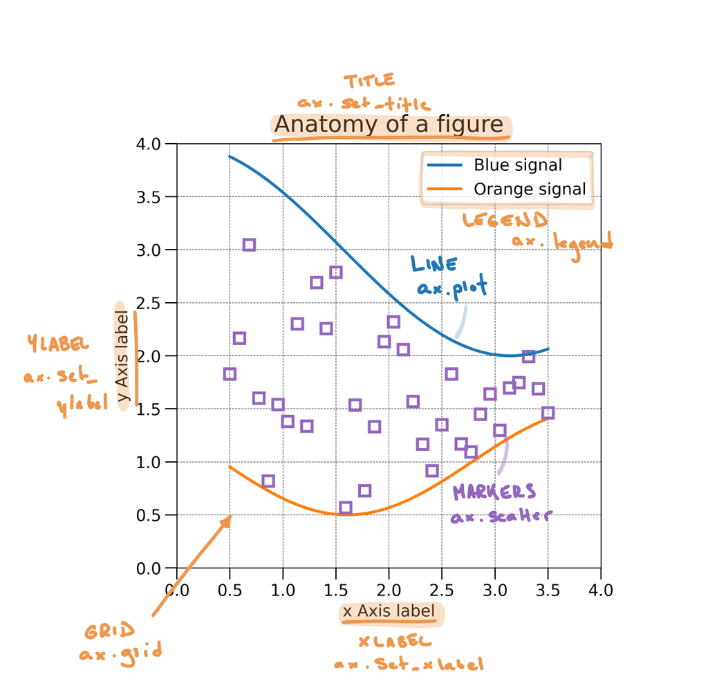

Figure 2: Basic components of a *Matplotlib* figure

**Plotting exercise**

Listing 3 defines a figure and plots some data. Table 1 and Figure 2 illustrate some of the most frequently used functions for customising plots.

Use these functions to customise Listing 3. Some hints:

- Remember that a *function* takes some *arguments* provided between *parentheses* (e.g., `ax.title(argument)`). Each function might accept different types of arguments.
- Titles and labels require a *string*, so remember to use `" "` or `' '`.
- For now, the legend does not require any argument, so you can leave the parentheses empty.
- Setting the grid requires one argument: do we want to show the grid (`True`) or not (`False`)

Table 1: Some of the most frequently used plotting functions.

| Function | Description | Argument Type | Example Argument |
| --- | --- | --- | --- |
| [`ax.set_title`](https://matplotlib.org/stable/api/_as_gen/matplotlib.axes.Axes.set_title.html) | Sets the title of the axes | str | “My Plot Title” |
| [`ax.set_xlabel`](https://matplotlib.org/stable/api/_as_gen/matplotlib.axes.Axes.set_xlabel.html) | Sets the label for the x-axis | str | “X Axis Label” |
| [`ax.set_ylabel`](https://matplotlib.org/stable/api/_as_gen/matplotlib.axes.Axes.set_ylabel.html) | Sets the label for the y-axis | str | “Y Axis Label” |
| [`ax.legend`](https://matplotlib.org/stable/api/_as_gen/matplotlib.axes.Axes.legend.html) | Displays the legend | None | None (default) |
| [`ax.grid`](https://matplotlib.org/stable/api/_as_gen/matplotlib.axes.Axes.grid.html) | Shows grid lines | bool | True |

Listing 3: Define a figure and one axes.

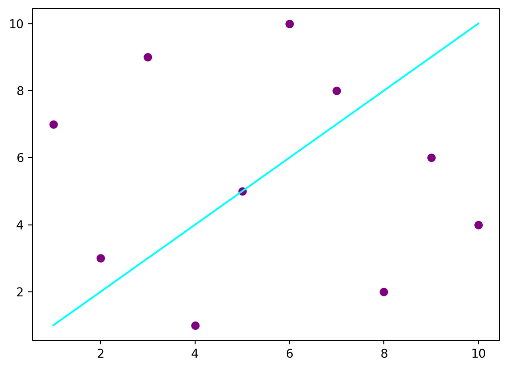

```python
import matplotlib.pyplot as plt # Import matplotlib

# Define some data
data1 = [1, 2, 3, 4, 5, 6, 7, 8, 9, 10]
data2 = [7, 3, 9, 1, 5, 10, 8, 2, 6, 4]

# Set the figure and the axes
fig, ax = plt.subplots()

# Plot the data
ax.plot(data1, data1, color='aqua', label='Line')
ax.scatter(data1, data2, color='purple', label='scatter')

# Customise the plot - up to you!
# - Add a title
# - Add x and y labels
# - Add a legend
# - Add a grid
```

### Plotting with Seaborn

Let’s now review the use of **Seaborn**. You might wonder why do we need another plotting library. Well, the topic of this module is data exploration, and this is exactly what *Seaborn* is designed for. In addition, *Seaborn* perfectly integrates with *Pandas* - isn’t that nice?

Over the next steps of the exercise we will use various types of plots offered by *Seaborn* to explore our geochemical dataset. Listing 4 illustrates how to create a [scatterplot](https://seaborn.pydata.org/generated/seaborn.scatterplot.html) of the Rubidium and Strontium values contained in our dataset `df_traces`. *Seaborn* usually takes 4 arguments:

1. `ax`: The axes on which to plot the data
2. `data`: The DataFrame containing the data.
3. `x`: The name of the column containing the values used along x
4. `y`: The name of the column containing the values used along y

Listing 4: Basic plotting using Seaborn.

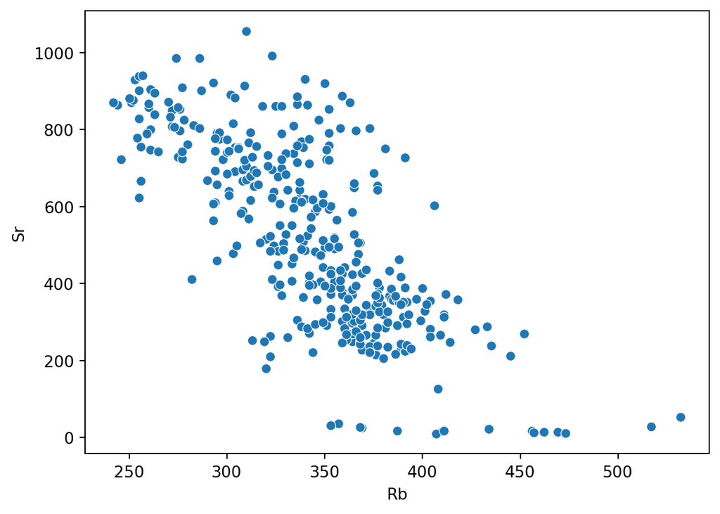

```python
# Define figure + axes
fig, ax = plt.subplots()
# Plot with seaborn (remember, we imported it as sns)
# df_traces is the geochemical dataset imported previously
sns.scatterplot(ax=ax, data=df_traces, x='Rb', y='Sr')
```

Should you feel adventurous and check out the [documentation](https://seaborn.pydata.org/generated/seaborn.scatterplot.html) of the `scatterplot` function, you would see that it is possible to use additional arguments to further customize the plot:

- `hue`: Name of the variable that will produce points with different colors.
- `size`: Name of the variable that will produce points with different sizes.

**Seaborn exercise**

Complete Listing 4, but use:

- The `"Epoch"` column to control points color.
- The `"SiO2* (EMP)"` column to control points size.

Remember, you can use `df.columns` to print a list of column names contained in the DataFrame.

- And if you are already done, take the time to explore and plot the `df_majors` dataset and plot some variables.

## Descriptive statistics

### Univariate analyses

The objective of **descriptive statistics** is to provide ways of capturing the properties of a given data set or sample. Using *Pandas* and *Seaborn*, we will review some metrics, tools, and strategies that can be used to summarize a dataset, providing us with a quantitative basis to talk about it and compare it to other datasets.

By **univariate analyses**, we focus on capturing the properties of **single** variables at the time. We are not yet concerned in characterising the relationships between two or more variables. The following sections introduce basic functions to visually analyse single variables and the most important parameters to describe them.

#### Initial visual analysis

Let’s focus on the Zircon concentration in Campi Flegrei’s geochemical dataset. We start by simply visualising the dataset to get an understanding of what we will talk about. The fist type of plot we will consider is a histogram, which shows the number of times a specific value occurs in a given variable. (Listing 5). In *Seaborn*, **Histograms** can be plotted using [`sns.histplots()`](https://seaborn.pydata.org/generated/seaborn.histplot.html), and (Listing 5) show the number of times a specific Zr concentration occurs in the dataset.

Note that **histograms** discretise the data into equal **bins**. The bin size (e.g., the width and numbers of bins) can alter the visual representation of the dataset. Although functions such as `sns.histplots()` rely on algorithm that suggest the optimal number of bins, it is a good practice to explore this parameter.

Listing 5: Visualising distributions using histograms.

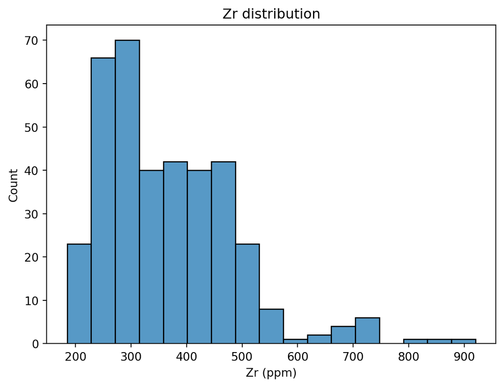

```python
fig, ax = plt.subplots()
sns.histplot(data=df_traces, x='Zr')
ax.set_xlabel('Zr (ppm)');
ax.set_title('Zr distribution');
```

**Your turn**

- Histograms discretise the data into equal **bins**. The documentation of [`sns.histplots()`](https://seaborn.pydata.org/generated/seaborn.histplot.html) shows that the function accepts various arguments (e.g., `bins`, `binwidth`, `binrange`) to modify how bins are defined. For now, let’s focus on the `bins` argument, which takes an `int` number defining the number of bins. The number of bins can critically alter the representation of a histogram. For instance, try:
  - `bins=10`
  - `bins=100`
- Try and plotting more than one column to `sns.histplots()` (→ provide a list of column names to `x`). How does it look? What are the limitations?

- The **location** - or where is the central value(s) of the dataset;
- The **dispersion** - or how spread out is the distribution of data compared to the central values;
- The **skewness** - or how symmetrical is the distribution of data compared to the central values;

#### Location

##### Mean

The **mean** (or *arithmetic* mean - by opposition to *geometric* or *harmonic* means) is the sum of the values divided by the number of values (Equation 1):

$$\bar{x} = \frac{1}{n} \sum_{i=1}^{n} x_i
\tag{1}$$

The mean is meaningful to describe **symmetric** distributions without **outliers**, where:

- **Symmetric** means the number of items above the mean should be roughly the same as the number below;
- **Outliers** are *extreme* values.

The mean of a dataset can easily be computed with *Pandas* using the [`.mean()`](https://pandas.pydata.org/docs/reference/api/pandas.DataFrame.mean.html) function (Listing 6). Note that we round the results to two significant digits using `.round(2)`.

Listing 6: Compute the mean for two significant digits.

```python
df_traces['Zr'].mean().round(2)
```

```
np.float64(365.39)
```

**Question**

What is the mean value for Strontium?

**Descriptive stats functions**

Listing 6 shows how to compute the mean on one column, but the `.mean()` function - as well as most fuctions for descriptive stats - can be applied to entire DataFrames. For this, we need to understand a critical argument - `axis`.

- `axis = 0` is usually the default, and computes the mean across all rows for each column(Listing 7)
- `axis = 1` usually makes sense when rows are labelled, and computes the mean across all columns for each row(Listing 8)

Listing 7: Compute the mean across rows.

```python
# Create a subset of the df_traces containing numerical data
df_traces_sub = df_traces[['Sc','Rb','Sr','Y','Zr','Nb','Cs']]
# Compute the mean across all rows
df_traces_sub.mean(axis=0).round(2).head()
```

```
Sc      0.20
Rb    343.81
Sr    516.42
Y      31.33
Zr    365.39
dtype: float64
```

Listing 8: Compute the mean across columns.

```python
# Create a subset of the df_traces containing numerical data
df_traces_sub = df_traces[['Sc','Rb','Sr','Y','Zr','Nb','Cs']]
# Compute the mean across all columns
df_traces_sub.mean(axis=1).round(2).head()
```

```
0    198.40
1    188.43
2    188.31
3    200.68
4    198.34
dtype: float64
```

##### Median

The **median** is the value at the exact middle of the dataset, meaning that just as many elements lie above the median as below it. There is no easy formula to compute the median, instead we need to conceptually (Listing 9):

1. Order all values in ascending order and plot them against a normalised number of observations (this is called an empirical cumulative density function - or ECDF);
2. On the x-axis, find the point dividing the dataset into two equal numbers of observations;
3. Read the value on the y-axis that intersects the ECDF.

Listing 9: Graphical representation of the median.

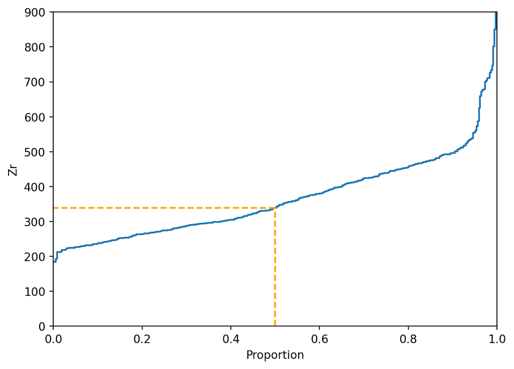

```python
fig, ax = plt.subplots()
sns.ecdfplot(data=df_traces, y='Zr')
ax.plot([.5,.5], [0, df_traces['Zr'].median()], color='orange', linestyle='--')
ax.plot([.5,0], [df_traces['Zr'].median(), df_traces['Zr'].median()], color='orange', linestyle='--')
ax.set_ylim([0,900])
```

Fortunately, we can also use the native *Pandas* [`.median`](https://pandas.pydata.org/docs/reference/api/pandas.DataFrame.median.html) function (Listing 10).

Listing 10: Compute the median for two significant digits.

```python
round(df_traces['Zr'].median(), 2)
```

```
np.float64(339.0)
```

**Question**

What is the median value for Cesium?

##### Mode

The mode is the value or values that occur most frequently in a dataset. Conceptually, it corresponds to the peak(s) of a histogram of the data. A distribution can have one mode (unimodal), two modes (bimodal), or multiple modes (multimodal). In *Pandas*, the mode is computed using [`.mode()`](https://pandas.pydata.org/docs/reference/api/pandas.DataFrame.mode.html).

For **categorical** or **discrete numerical data**, the mode simply the value(s) that appear most often.

For **continuous data**, exact duplicates may be rare, and resulting modes might not be that meaningful (Figure 3). As a result, we often bin the data into intervals first and find the most populated bin (Figure 4).

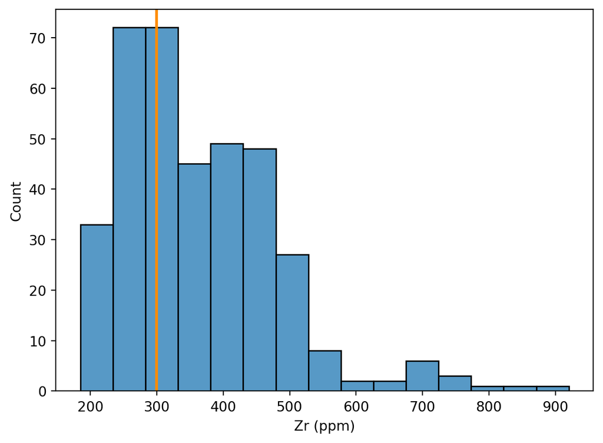

Figure 3: Modes computed from a continuous dataset.

```python
# Calculate the modes
modes = df_traces['Zr'].mode().round(2)

# Set the histogram's bin width
binwidth = 50

# Plot the histogram
fig, ax = plt.subplots()
sns.histplot(data=df_traces, x='Zr', ax=ax, binwidth=50)

# Plot the modes
for i, m in enumerate(modes):
    ax.axvline(m, color='darkorange', lw=2)

ax.set_xlabel('Zr (ppm)')

plt.show()
```

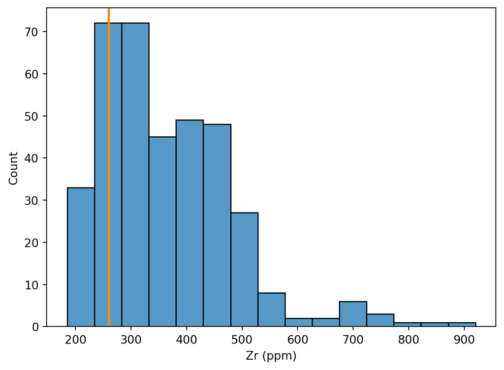

Figure 4: Modes computed from a binned dataset.

```python
# Set the histogram's bin width
binwidth = 50

# Make the bin range
minVal = int(df_traces['Zr'].min()) # Minimum value of the dataset, convert it to an integer
maxVal = int(df_traces['Zr'].max()) # Maximum value of the dataset, convert it to an integer
binsVal = range(minVal, maxVal, binwidth)
binned = pd.cut(df_traces['Zr'], bins=binsVal)
modes = binned.mode();


# Convert modes to numeric positions (handles numeric modes and Interval modes from pd.cut)
numeric_modes = []
for m in modes:
    numeric_modes.append((m.left + m.right) / 2)  # midpoint of the interval

# Plot the histogram
fig, ax = plt.subplots()
sns.histplot(data=df_traces, x='Zr', ax=ax, binwidth=50)

# Plot the modes
for i, mval in enumerate(numeric_modes):
    ax.axvline(mval, color='darkorange', lw=2)

ax.set_xlabel('Zr (ppm)')

plt.show()
```

##### Summary

Listing 11 illustrate the values of the mean and the median relative to the distribution shown in the histogram. There are a few things to keep in mind when choosing between mean and median to estimate the location of a dataset:

- If a sample has a symmetrical distribution, then **the mean and median are equal**.
- If the distribution of a sample is not symmetrical, **the mean should not be used**.
- The mean is highly sensitive to outliers, whereas the median is not.

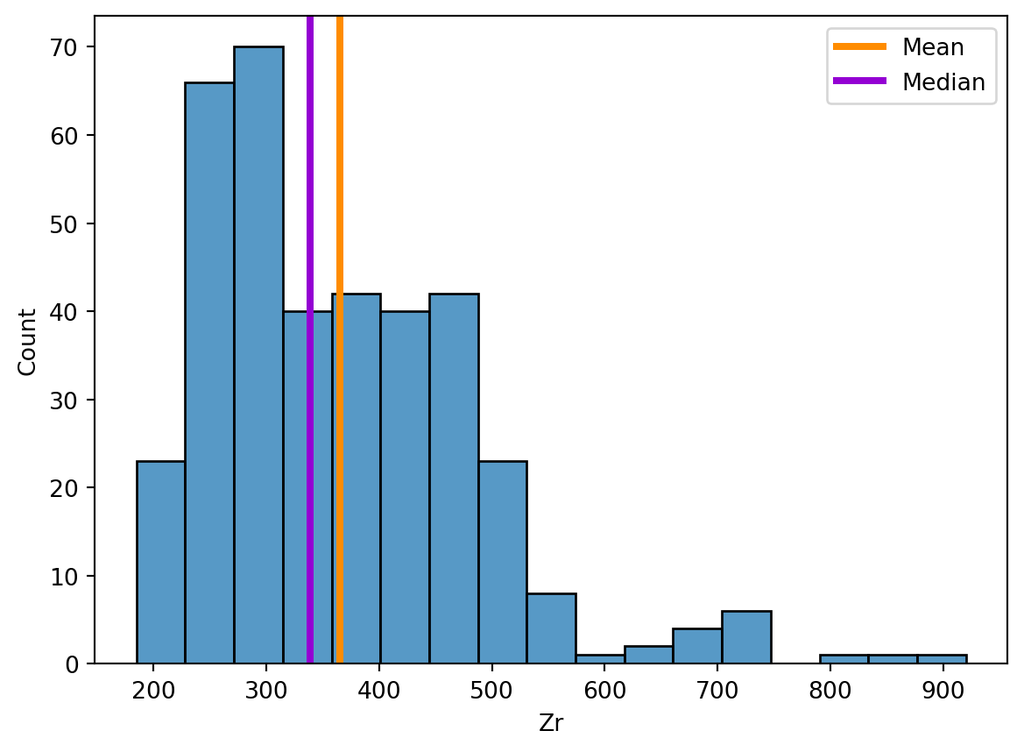

```python
fig, ax = plt.subplots()
sns.histplot(data=df_traces, x='Zr')
ax.axvline(df_traces['Zr'].mean(), color='darkorange', lw=3, label='Mean')
ax.axvline(df_traces['Zr'].median(), color='darkviolet', lw=3, label='Median')
ax.legend()
```

#### Dispersion

##### Range

The first information we might want to get for a dataset is the range of values it covers, or *range*. For this, we need to get the minimum (`df.min()`) and maximum (`df.max()`) values, from which, when needed, the range can be calculated with Equation 2. It is however likely that the min/max functions will be more frequently used (Listing 12).

$$\text{Range} = \max(x) - \min(x)
\tag{2}$$

Listing 12: Compute the min and the max values of a column

```python
df_traces['Zr'].min()
df_traces['Zr'].max()
```

```
np.int64(920)
```

**Question**

What is the mean value for Cesium?

##### Variance and standard deviation

The **variance** and **standard deviation** are two key measures of dispersion that describe how spread out the values in a dataset are.

- **Standard deviation** ($\sigma$) measures sum of squares differences between data points $x_i$ and the mean $\bar{x}$:
  $$\sigma = \sqrt{\frac{\sum_{i=1}^{n} (x_i - \bar{x})^2}{n-1} }$$
  where $x_i$ are the data points, $\bar{x}$ is the mean, and $n$ is the number of observations.
- **Variance** ($\sigma^2$) is the square of the standard deviation:
  $$\sigma^2 = \frac{\sum_{i=1}^{n} (x_i - \bar{x})^2}{n-1}$$

For now we will consider that they roughly measure the same thing. The standard deviation is in the same units as the data, making it easier to interpret.

**Relation to the Gaussian distribution:**  
For a Gaussian (normal) distribution, about 68% of the data falls within one standard deviation of the mean, about 95% within two standard deviations, and about 99.7% within three standard deviations. Thus, variance and standard deviation are fundamental for describing the spread and probability intervals of normally distributed data.

You can compute these in pandas using `.var()` and `.std()`:

Listing 13: Compute the variance and standard deviation across columns.

```python
# Compute the variance of a single column:
df_traces['Zr'].var()
# Compute the standard deviation of all columns in the DataFrame. In this case, you need to make sure that all columns are numerical.
df_traces_sub.std()
```

```
Sc      0.095893
Rb     46.941294
Sr    241.911792
Y       7.369804
Zr    118.393583
Nb     18.185571
Cs      6.851637
dtype: float64
```

##### Interquartile range

If the **standard deviation** is valid only for symmetrical distributions, what can we use for asymmetrical ones? The **interquartile range** can help, but we first need to define what are **percentiles**. We previously saw that the median represents the value at the middle of the dataset, which means that:

- Half of the data points is **greater** than the median;
- The other half is **smaller** than the median.

The **median** therefore represents the **50<sup>th</sup> percentile** of the dataset. In a similar way, we can ask ourselves:

- *What is the value below which lie 25% of the data?* → **25<sup>th</sup> percentile**;
- *What is the value below which lie 75% of the data?* → **75<sup>th</sup> percentile**.

Figure 5 and Figure 6 show the relationship between the percentiles and the underlying distribution of data, where:

- The blue area shows the histogram (→ **how many** data points fall into a specific bin = discrete range of values?)
- The orange curve shows the cumulative function (→ **what proportion** of data falls below a specific value?)

Figure 5 shows the percentiles of a **symmetric** distribution, and demonstrates how i) the median value **is equal** to the mean and ii) the 25<sup>th</sup>and 75<sup>th</sup> percentile are **equally dispersed** around the median. In contrast, for **asymmetric** distributions, Figure 6 shows that i) the median and mean values **increasingly diverge** and ii) the 25<sup>th</sup>and 75<sup>th</sup> percentile are **asymmetrically dispersed** around the median.

```python
# Import the libraries
import numpy as np
import matplotlib.pyplot as plt
import seaborn as sns
from matplotlib.patches import FancyArrowPatch

# Function to plot the arrow
def plotArrow(ax,data,pct,c):
    arrowH = FancyArrowPatch(
        (ax.get_xlim()[1], pct/100), (np.percentile(data, pct), pct/100),
        arrowstyle='-|>',  # style: arrow with single head
        color=c,
        mutation_scale=15,  # size of arrow head
        linewidth=2
    )
    ax.add_patch(arrowH)

    value = np.percentile(data, pct)
    ax.text(8, pct/100 + 0.03, f"{pct}th: {value:.2f}", color=c, ha='center', va='bottom', fontsize=12, fontweight='bold')

    arrowD = FancyArrowPatch(
        (np.percentile(data, pct), pct/100), (np.percentile(data, pct), 0),
        arrowstyle='-|>',  # style: arrow with single head
        color=c,
        mutation_scale=15,  # size of arrow head
        linewidth=2
    )
    ax.add_patch(arrowD)
    # Plot the mean as a vertical red dotted line on the histogram axis
    ax.axvline(data.mean(), color='red', linestyle=':', linewidth=2)

# Define the colours for plotting
blue = '#2F4647'
orange = '#EB811B'

# Setup random data using a Normal distribution
data = np.random.normal(size=1000)
data = (data - data.min()) / (data.max() - data.min())*10
datapct = np.percentile(data, [10, 25, 50, 75, 90])

# Set the plots
fig, ax = plt.subplots(figsize=(6, 4))

# Left y axis
sns.histplot(x=data, bins=20, color=blue, alpha=0.4, ax=ax, label='Density', element='step')
ax.set_xlabel('Data value (arbitrary)')
ax.set_ylabel('Count (= number of data points \nin each bin)', color=blue)
ax.tick_params(axis='y', labelcolor=blue)
ax.set_title('Percentiles of a symmetric distribution', fontweight='bold')

# Add a right y axis
ax2 = ax.twinx()
sns.ecdfplot(x=data, ax=ax2, color=orange, label='Cumulative density')
ax2.set_ylabel('CDF (= proportion of data\n points below the data value)', color=orange)
ax2.tick_params(axis='y', labelcolor=orange)

# Plot the arrows
plotArrow(ax2, data, 75, '#1D6996')
plotArrow(ax2, data, 50, '#0F8554')
plotArrow(ax2, data, 25, '#994E95')

fig.tight_layout()

fig.savefig("img/fig-univ-pctS.png", dpi=150, transparent=True)
plt.close(fig)
```

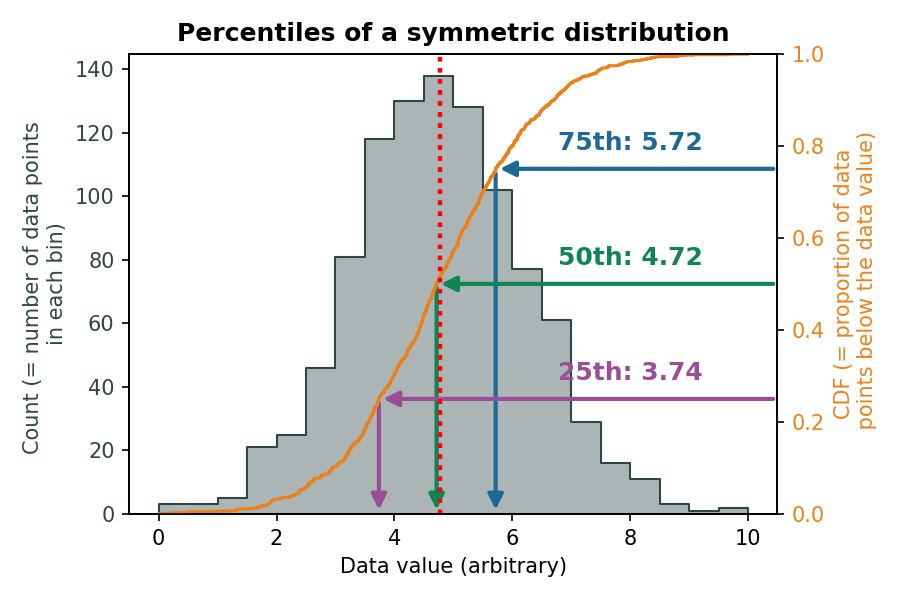

Figure 5: Relationship of percentiles to a symmetric distribution. The red dotted line shows the location of the mean.

```python
# Setup random data using a log-normal distribution
data = np.random.lognormal(size=1000, sigma=.4)
data = (data - data.min()) / (data.max() - data.min())*10
datapct = np.percentile(data, [10, 25, 50, 75, 90])

# Set the plots
fig, ax = plt.subplots(ncols=1, figsize=(6, 4))

# Left y axis
sns.histplot(x=data, bins=20, color=blue, alpha=0.4, ax=ax, legend=None, element='step')
ax.set_xlabel('Data value (arbitrary)')
ax.set_ylabel('Count (= number of data points \nin each bin)', color=blue)
ax.tick_params(axis='y', labelcolor=blue)
ax.set_title('Percentiles of an asymmetric distribution', fontweight='bold')

# Add a right y axis
ax2 = ax.twinx()
sns.ecdfplot(x=data, ax=ax2, color=orange, legend=None)
ax2.set_ylabel('CDF (= proportion of data\n points below the data value)', color=orange)
ax2.tick_params(axis='y', labelcolor=orange)

# Plot the arrows
plotArrow(ax2, data, 75, '#1D6996')
plotArrow(ax2, data, 50, '#0F8554')
plotArrow(ax2, data, 25, '#994E95')

fig.tight_layout()
fig.savefig("img/fig-univ-pctA.png", dpi=150, transparent=True)
plt.close(fig)
```

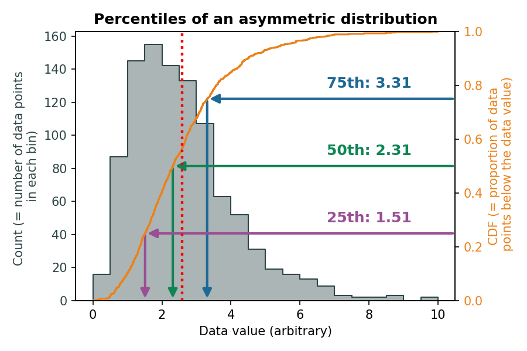

Figure 6: Relationship of percentiles to a asymmetric distribution. The red dotted line shows the location of the mean.

The **interquartile range** ($IQR$) is the spread between the first ($Q_1$) and the third ($Q_3$), quartiles, which represent the 25<sup>th</sup> and 75<sup>th</sup> percentiles, respectively (see Table 2 and Tip 1 for a relationship between percentiles, quartiles and deciles). It is simply computed as (Equation 3), and represents a range within which **50% of the data points** lie.

$$\mathrm{IQR} = Q_3 - Q_1
\tag{3}$$

**Tip 1: Quartiles, deciles and percentiles**

Using proportions of the dataset as measures of central tendencies and spread can be done using different strategies to divide the distribution, but they really refer to the same underlying values. Table 2 summarises the differences between quartiles, deciles and percentiles.

Table 2: Relationship between quartiles, deciles and percentiles.

| **Measure** | **Number of Divisions** | **Position(s) in Data / Percentile Equivalent** | **Description** |
| --- | --- | --- | --- |
| **Quartiles (Q1, Q2, Q3)** | 4 equal parts | Q1 = 25th percentile, Q2 = 50th percentile (median), Q3 = 75th percentile | Divides data into 4 equal-sized groups |
| **Deciles (D1 … D9)** | 10 equal parts | D1 = 10th percentile, D2 = 20th percentile, …, D9 = 90th percentile | Divides data into 10 equal-sized groups |
| **Percentiles (P1 … P99)** | 100 equal parts | P1 = 1st percentile, P2 = 2nd percentile, …, P99 = 99th percentile | Divides data into 100 equal-sized groups |

#### Skewness

The **skewness** measures the asymmetry of a distribution and is computed as Equation 4:

$$\text{Skewness} = \frac{1}{n} \sum_{i=1}^{n}\left(\frac{x_i-\bar{x}}{s}\right)^{3}
\tag{4}$$

In *Pandas*, the skewness can be computed using `.skew()` (Listing 14). The returned value indicates:

- **0**: Symmetric → e.g., normal distribution
- **>0**: Righ-skewed → a tail extends to the right
- **<0**: Left-skewed → a tail extends to the left

Listing 14: Skewness of the `Zr` dataset.

```python
df_traces['Zr'].skew().round(2)
```

```
np.float64(1.27)
```

#### Box-and-whiskers plots

Although relying on percentiles - which better account for asymmetrical distributions, the $IQR$ still represents a range that does not convey the shape of the underlying distribution. Reporting a few percentiles (e.g., 10-90, 25-75) typically better convey an idea of spread and distribution shape. Note that this is the idea behind **box plots** (or **box and whiskers plots**; Figure 7), which attempt to provide all components of the underlying distribution (e.g., location, dispersion, skewness) in a non-paramteric way:

- The **box** represents the 25<sup>th</sup> and 75<sup>th</sup> percentiles → $IQR$;
- The **horizontal line** within the **box** represents the **median**;
- The **whiskers** reprents a range that usually extends 1.5 times the IQR from the first and third quartiles
- Any point that lies beyond the whiskers is considered an **outlier**, which is a point that significantly different from the majority of observations.

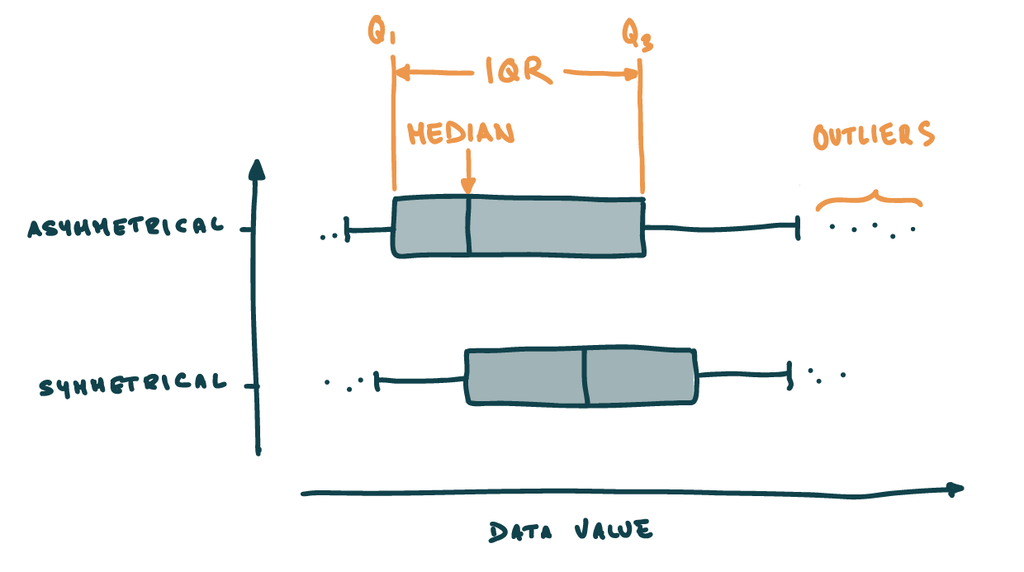

Figure 7: Component of a box and whiskers plot. The top box plot represents an asymmetrical distribution, the bottom one a symmetrical one.

In *Seaborn*, box plots can be plotted using [`sns.boxplot()`](https://seaborn.pydata.org/generated/seaborn.boxplot.html). Two notes about box plots:

1. They are useful to compare the **location** and **dispersion** between variables (Listing 15);
2. In *Seaborn*, whiskers extend by default 1.5 times the IQR from the first and third quartiles. This behaviour can be altered with the `whis` argument of `sns.boxplot()` (see the [doc](https://seaborn.pydata.org/generated/seaborn.boxplot.html))

*Seaborn* offers two alternatives to boxplots:

1. **Violin plots** ([`sns.violinplot()`](https://seaborn.pydata.org/generated/seaborn.violinplot.html)) are similar to box plots, but they approximate the underlying parametric data distribution using some smoothing algorithm (i.e. *kernel density estimation*). Without going into too much detail, this provides a good first approximation of the distribution, but it can create some unrealistic artefacts (e.g., see the negative Sr concentrations in Listing 16).
2. **Boxen plots** ([`sns.boxenplot()`](https://seaborn.pydata.org/generated/seaborn.boxenplot.html)) are designed to better represent the non-parametric distriubtion of large dataset than box plots. They divide the datasets into **many quantiles** (not just Q1-Q3), and typically provide more resolution in the **tails** of the distribution (Listing 17).

Table 3 provides a cheat sheet on which plot to use.

**Box plot**

Listing 15: Visualising distributions using box-and-whisker plots.

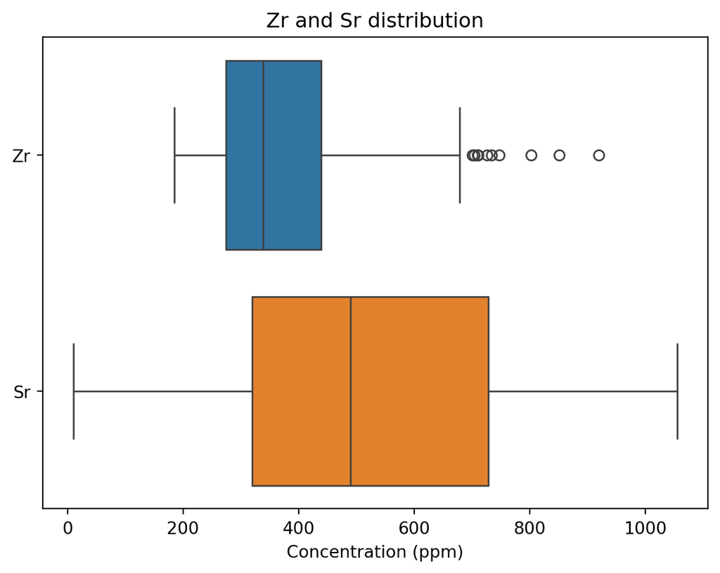

```python
fig, ax = plt.subplots()
sns.boxplot(data=df_traces[['Zr', 'Sr']], orient="h", ax=ax)
ax.set_xlabel('Concentration (ppm)');
ax.set_title('Zr and Sr distribution');
```

**Violin plot**

Listing 16: Visualising distributions using violin plots.

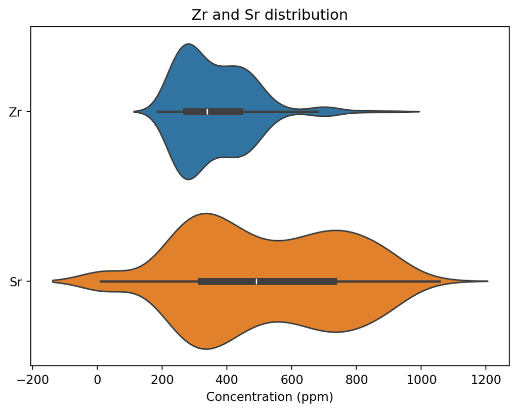

```python
fig, ax = plt.subplots()
sns.violinplot(data=df_traces[['Zr', 'Sr']], orient="h", ax=ax)
ax.set_xlabel('Concentration (ppm)');
ax.set_title('Zr and Sr distribution');
```

**Boxen plots**

Listing 17: Visualising distributions using boxen plots.

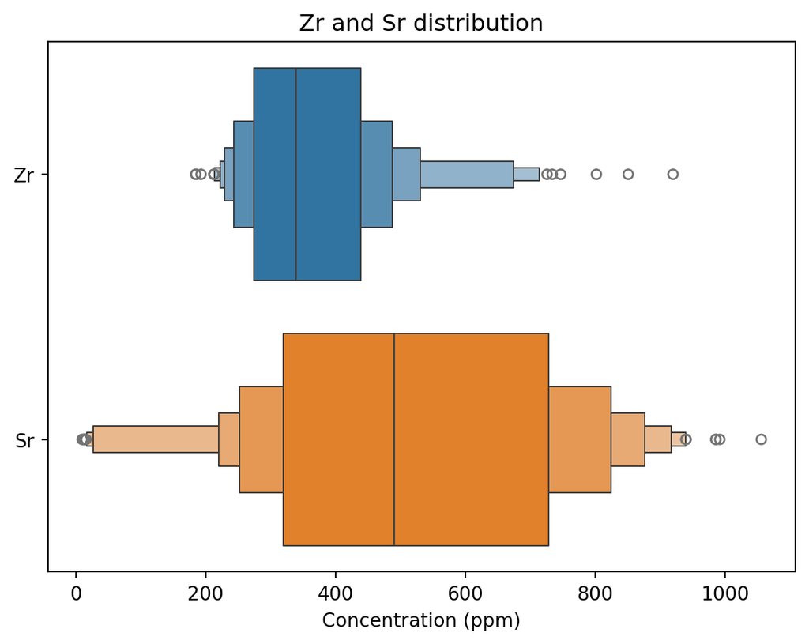

```python
fig, ax = plt.subplots()
sns.boxenplot(data=df_traces[['Zr', 'Sr']], orient="h", ax=ax)
ax.set_xlabel('Concentration (ppm)');
ax.set_title('Zr and Sr distribution');
```

Table 3: Simple rules on which plot to choose to represent data distributions.

| Feature | Box Plot | Boxen Plot | Violin Plot |
| --- | --- | --- | --- |
| Data size | Small/medium | Large | Any |
| Shows tails well? | No | Yes | Yes |
| Shows data density? | No | No | Yes |
| Complexity | Simple | Moderate | High |
| Implementation | `sns.boxplot()` | `sns.boxenplot()` | `sns.violinplot()` |

**Your turn**

Take some time to get familiar with the use of these plotting functions!

- Plot different/more variables
- Check out the documentation
- Ask questions!

#### Grouping variables

Cool, we now have the tools to describe the behaviour of single numerical variables. However, as described here, we see that our dataset also contains categorical variables, and we are going to see now how we can exploit them to apply what we just learned on **specific categories** of our dataset.

For the sake of simplicity, let’s make a subset of the trace elements dataset, from which we select:

1. 5 numerical data → *U*, *Sc*, *Hf*, *Zr*, *Sr*
2. 1 categorical data → *Epoch*

*Panda* as a very handy function to group data by categorical variables: `.groupby` ([doc](https://pandas.pydata.org/pandas-docs/stable/reference/api/pandas.DataFrame.groupby.html)). Let’s compute the mean value of the different trace elements for each epoch (Listing 18):

Listing 18: Grouping data and computing the mean

```python
df_traces_sub = df_traces[['Epoch', 'U', 'Sc', 'Hf', 'Zr', 'Sr']]
df_traces_sub.groupby(by='Epoch').mean()
```

| Epoch | U | Sc | Hf | Zr | Sr |
| --- | --- | --- | --- | --- | --- |
| one | 7.191429 | 0.271905 | 5.892381 | 257.158730 | 786.785714 |
| three | 11.789247 | 0.148387 | 9.159677 | 407.204301 | 390.268817 |
| three-b | 10.908583 | 0.138083 | 8.455917 | 392.716667 | 422.466667 |
| two | 15.088387 | 0.272581 | 12.776774 | 574.064516 | 147.800000 |

Pretty handy don’t you think? Note that you can apply all the functions described above (e.g., `.median()` or `.percentiles()`) to a `groupby` object.

**Question**

- Try and apply other statistical functions to your dataset.
- Looking at the [documentation](https://pandas.pydata.org/pandas-docs/stable/reference/api/pandas.DataFrame.groupby.html), it seems the `by` argument accepts a *label* (which is what we use in Listing 18) or a *list of labels*. Could it be that we can use more than one grouping variable? Such as `'Epoch'` and `'Eruption'`?

### Bivariate analyses

Up to now, the domain of univariate analyses has allowed us to explore the properties of **one variable at the time**. Investigating the relationship between **two variables** is the topic of bivariate analyses. One good visual starting point is to plot **pairwise relationships** of all the variables in our dataset.

Let’s go back to our `df_traces_sub` dataset. We can then plot a pairwise comparison plot using *Seaborn*’s `.pairplot()` function ([doc](https://seaborn.pydata.org/generated/seaborn.pairplot.html); Listing 19). We use the `hue` argument of th `.pairplot()` function to plot each epoch as a different color:

Listing 19: Pairwise comparison plot using Seaborn

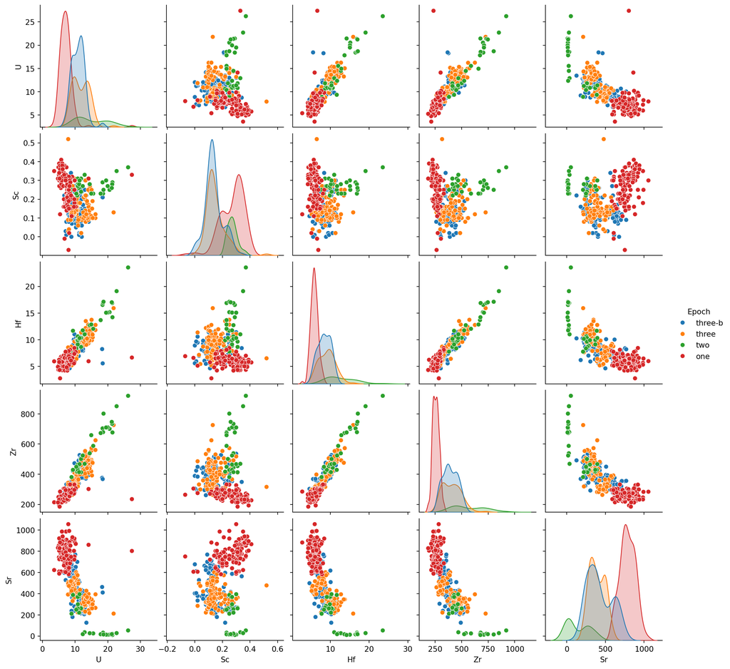

```python
df_traces_sub = df_traces[['Epoch', 'U', 'Sc', 'Hf', 'Zr', 'Sr']]
sns.pairplot(data=df_traces_sub, hue='Epoch')
```

**Your turn!**

For single variables:

- Based on the parameters described in the previous section and looking at histograms (i.e., the diagonal plot), how would you describe their **distributions** of values?
- Do they vary across eruptive epochs?

Now, thinking about the relationship between **two variables**:

- What variables behave in a similar way?
- What variables don’t?
- Do you see any **clustering** emerge?

#### Correlation

From Listing 19 we can fairly intuitively infer that some variables show coupled behaviours (e.g., *Zr* tends to increase whe *Hf* does), whereas the behaviour of other variables suggests much less coupling (e.g., *Sc* and *Hf*).

The first measure used to quantify the joint variability of two variables $x$ and $y$ is the **covariance** (Equation 5).

$$Cov_{xy} = \frac{1}{n-1}\sum_{i=1}^n (x_i - \bar{x})(y_i - \bar{y})
\tag{5}$$

The covariance depends on the magnitudes of the two variables inspected and, consequently, it does not inform much about the strength of the relationship. The **correlation coefficient** (Equation 6) represents a normalized version of the covariance that allows to overcome this limitation. The correlation coefficient ranges from −1 to 1 and shows, by its magnitude, the strength of the linear relation.

$$r_{xy} = \frac{Cov_{xy}}{\sigma_x \sigma_y} = \frac{\sum_{i=1}^n (x_i - \bar x)(y_i - \bar y)}{\sqrt{\sum_{i=1}^n (x_i - \bar x)^2}\;\sqrt{\sum_{i=1}^n (y_i - \bar y)^2}}
\tag{6}$$

- $r_{xy} >0$ indicates a **positive relationship** between $x$ and $y$ (→ $y$ increases when $x$ does);
- $r_{xy} <0$ indicates a **negative relationship** between $x$ and $y$ (→ $y$ decreases when $x$ increases);
- $r_{xy} =0$ indicates **independence** between $x$ and $y$.

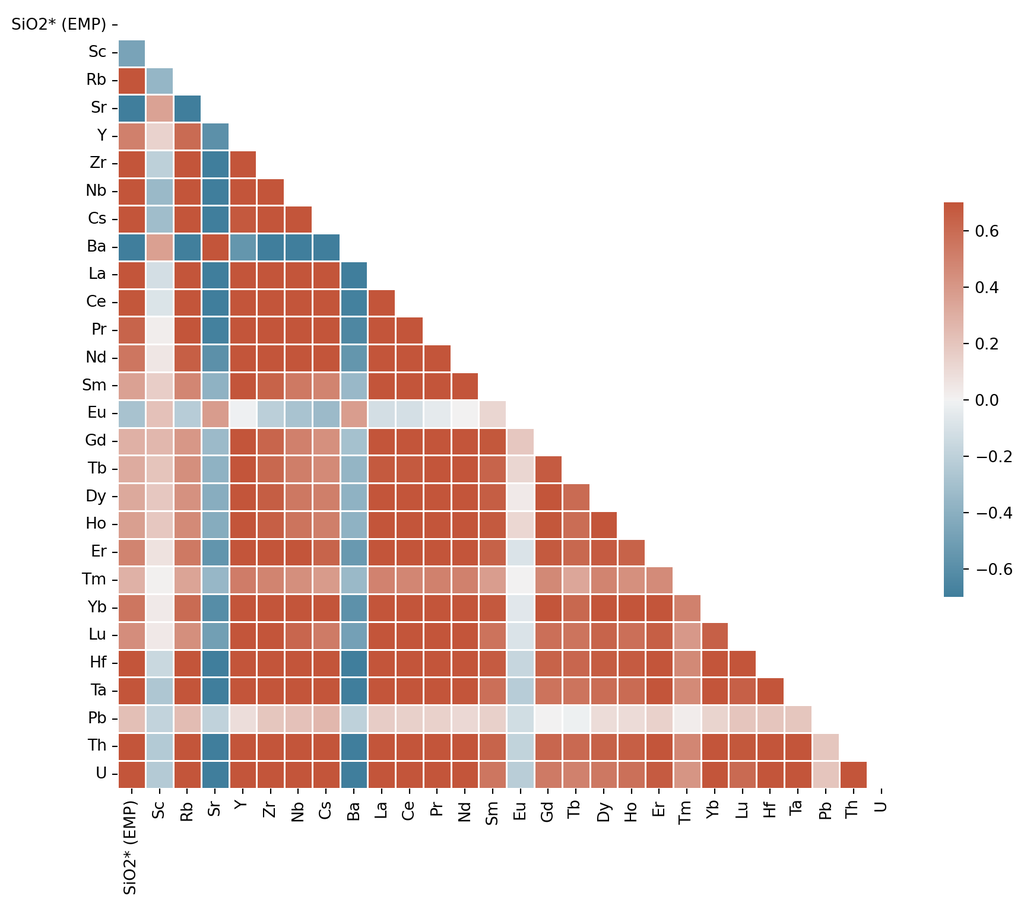

```python
# Define a function to plot the correlation matrix. It takes one argument (i.e., a DataFrame)
def corrMatrix(d):

    # Compute the correlation matrix
    corr = d.corr()

    # Generate a mask for the upper triangle
    mask = np.triu(np.ones_like(corr, dtype=bool))

    # Set up the matplotlib figure
    f, ax = plt.subplots(figsize=(11, 9))

    # Generate a custom diverging colormap
    cmap = sns.diverging_palette(230, 20, as_cmap=True)

    # Draw the heatmap with the mask and correct aspect ratio
    sns.heatmap(corr, mask=mask, cmap=cmap, vmax=.7, vmin=-.7, center=0,
                square=True, linewidths=.5, cbar_kws={"shrink": .5})


# Keep only the numerical columns, i.e., from column index 9 to the last
df_traces_sub = df_traces.iloc[:, 9:]
corrMatrix(df_traces_sub)
```

Petrelli, Maurizio. 2021. *Introduction to Python in Earth Science Data Analysis: From Descriptive Statistics to Machine Learning*. Springer Textbooks in Earth Sciences, Geography and Environment. Springer Cham. https://doi.org/10.1007/978-3-030-78055-5.

Smith, V. C., R. Isaia, and N. J. G. Pearce. 2011. “Tephrostratigraphy and Glass Compositions of Post-15 Kyr Campi Flegrei Eruptions: Implications for Eruption History and Chronostratigraphic Markers.” *Quaternary Science Reviews* 30 (25-26): 3638–60. https://doi.org/10.1016/j.quascirev.2011.07.012.